# SI 370 - Homework #1: Data Manipulation and Preliminary Analyses

## Background

This homework assignment focuses on the exploration and analysis of historical data from the Olympic games. The description of the data includes the following:

> This is a historical dataset on the modern Olympic Games, including all the Games from Athens 1896 to Rio 2016. I scraped this data from www.sports-reference.com in May 2018.

Your main task in this assignment is to explore the data *using the data manipulation and analysis methods we covered in class* as well as those in the assigned readings. You may need to consult pandas documentation, Stack Overflow, or other online resources.

**You should also feel free to ask questions on the **[class Slack channel](https://si370fa2018.slack.com/messages/CCQLTNS65/team/UCFLDB049/)** !**

A total of 30 points is available in this homework assignment.

Each of Questions 1-5 are worth 5 points each. Points will be allocated according to the following rubric:

- 5 points: Question is correctly and completely answered. Answer consists of well-written code that conforms to [PEP 8](https://www.python.org/dev/peps/pep-0008/) guidelines and is accompanied by a written interpretation in a Markdown block. Written interpretation does not contain spelling, grammar or stylistic errors (see https://faculty.washington.edu/heagerty/Courses/b572/public/StrunkWhite.pdf for a detailed specifications).
- 4 points: Answer is mostly complete and correct; two or fewer noticeable omissions or errors. Minor stylistic flaws, either in code or in written interpretation.
- 3 points: Answer has significant omissions or errors; Noticeable departure from PEP-8 guildelines and/or moderate spelling, grammar, or style issues in written interpretations.
- 2 points: Question is perfunctorily attempted. Substantial parts are missing or incorrect.
- 0 points: Question not attempted.

A bonus question worth up to 5 points is also available.

## First, Download the data (athlete_events.csv) from:

- https://www.kaggle.com/heesoo37/120-years-of-olympic-history-athletes-and-results

## Answer the questions below.

For each question, you should

1. Write code using Python and pandas that can help you answer the following questions, and
2. Explain your answers in plain English. You should use complete sentences that would be understood by an educated professional who is not necessarily a data scientist (like a product manager).

### Q1 Load and describe the dataset. (5pt)

- How many number rows and columns are there in the data frame?
- Provide summary statistics (i.e. use the .describe() function) for the numeric variables (other than ID) from the athlete_events.csv file.

```python
# put your code here
import pandas as pd
df = pd.read_csv('olympic_data/athlete_events.csv')
df.head(2)
df.describe()
```

|  | ID | Age | Height | Weight | Year |
| --- | --- | --- | --- | --- | --- |
| count | 271116.000000 | 261642.000000 | 210945.000000 | 208241.000000 | 271116.000000 |
| mean | 68248.954396 | 25.556898 | 175.338970 | 70.702393 | 1978.378480 |
| std | 39022.286345 | 6.393561 | 10.518462 | 14.348020 | 29.877632 |
| min | 1.000000 | 10.000000 | 127.000000 | 25.000000 | 1896.000000 |
| 25% | 34643.000000 | 21.000000 | 168.000000 | 60.000000 | 1960.000000 |
| 50% | 68205.000000 | 24.000000 | 175.000000 | 70.000000 | 1988.000000 |
| 75% | 102097.250000 | 28.000000 | 183.000000 | 79.000000 | 2002.000000 |
| max | 135571.000000 | 97.000000 | 226.000000 | 214.000000 | 2016.000000 |

### Q2 Describe the distribution of heights, weights and ages using appropriate plots. Comment on whether the distributions appear to be normally distributed. (5pt)

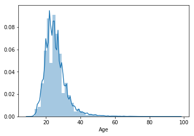

```python
# put your code here
import seaborn as sns

%matplotlib inline
ages = df.dropna(subset=["Age"])
sns.distplot(ages["Age"]);
```

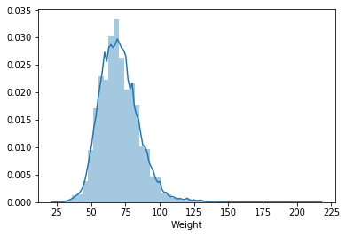

```python
%matplotlib inline
weights = df.dropna(subset=["Weight"])
sns.distplot(weights["Weight"])
```

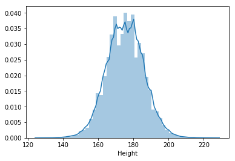

```python
%matplotlib inline
heights = df.dropna(subset=["Height"])
sns.distplot(heights["Height"])
```

The distribution for age is not normally distributed, instead it is a unimodal distribution that is skewed right. The distribution for age follows a similar pattern to the distribution for age; it is also a unimodal distribution skewed right. The distribution for height is normal.

### Q3 Which athlete competed in the most number of events? (5pt)

In which events did the athelete participate, and for what range of years? Which country did the athlete represent?

```python
# put your code here

#finding most # of events
max_counts = df["Name"].value_counts()
athlete_name = max_counts.head(1).index[0]
print(athlete_name)

#finding events athlete participated in
most_events = df[df['Name'] == athlete_name]
print(most_events["Event"].unique().tolist())

#finding which years athlete participated in
earliest_year = most_events['Year'].min()
latest_year = most_events['Year'].max()

print(earliest_year)
print(latest_year)

#country for athlete
print(most_events["Team"].unique().tolist())

#find the 2nd person's name
athlete_2 = max_counts.head(2).index[1]
print(athlete_2)

#find the 2nd person's events
athlete_2_events = df[df["Name"] == athlete_2]
print(athlete_2_events["Event"].unique().tolist())

#find the years 2nd athlete participated in
print(athlete_2_events["Year"].min())
print(athlete_2_events["Year"].max())

#country for athlete
print(athlete_2_events["Team"].unique())
```

```
Robert Tait McKenzie
['Art Competitions Mixed Sculpturing', 'Art Competitions Mixed Sculpturing, Statues', 'Art Competitions Mixed Sculpturing, Medals And Reliefs', 'Art Competitions Mixed Sculpturing, Unknown Event', 'Art Competitions Mixed Sculpturing, Medals']
1912
1948
['Canada']
Heikki Ilmari Savolainen
["Gymnastics Men's Individual All-Around", "Gymnastics Men's Team All-Around", "Gymnastics Men's Horse Vault", "Gymnastics Men's Parallel Bars", "Gymnastics Men's Horizontal Bar", "Gymnastics Men's Rings", "Gymnastics Men's Pommelled Horse", "Gymnastics Men's Floor Exercise"]
1928
1952
['Finland']
```

Robert Tait McKenzie competed in the most events. He competed in the following events: 'Art Competitions Mixed Sculpturing', 'Art Competitions Mixed Sculpturing, Statues', 'Art Competitions Mixed Sculpturing, Medals And Reliefs', 'Art Competitions Mixed Sculpturing, Unknown Event', 'Art Competitions Mixed Sculpturing, Medals.' He participated in the Olympics from 1912 to 1948, representing Canada. However, upon closer investigation these events do not necessarily seem to be athletic events, therefore, we must look at the second person on the list. That athlete is Heikki Ilmari Savolainen, who participated in "Gymnastics Men's Individual All-Around", "Gymnastics Men's Team All-Around", "Gymnastics Men's Horse Vault", "Gymnastics Men's Parallel Bars", "Gymnastics Men's Horizontal Bar", "Gymnastics Men's Rings", "Gymnastics Men's Pommelled Horse", and "Gymnastics Men's Floor Exercise." He participated from 1928 to 1952, representing Finland.

### Q4 Which sport has the highest median athlete age? (5pt)

To determine this, you might want to calculate and plot the median age for each sport. You may want to sort the axes appropriately for your analysis.

```python
# put your code here
median_ages = df.groupby("Sport")["Age"].median()
median_ages.max()
sport = median_ages[median_ages == median_ages.max()]
sport
```

```
Sport
Roque    59.0
Name: Age, dtype: float64
```

Roque is the sport with the highest median athlete age.

### Q5 Which countries have more female medalists than male medalists? (5pt)

```python
# put your code here
medals = df[pd.notnull(df["Medal"])]
medals["total_medal_count"] = 1
medals_mapped = medals.groupby(['Team', 'Sex'])['total_medal_count'].agg('sum')
medals_gender = medals_mapped.to_frame().reset_index()

# medals_gender
country_list = medals_gender.Team.value_counts()
duplicate_country_list = medals_gender[medals_gender.Team.isin
                         (country_list.index[country_list.gt(1)])]

#
medals_by_sex = duplicate_country_list.groupby('Team').apply(lambda x: x.nlargest(1, 'total_medal_count')).reset_index(drop=True)
greater_females = medals_by_sex[(medals_by_sex['Sex'] == 'F')]
more_females_list = greater_females['Team'].tolist()

more_females_list
```

```
['Belarus',
 'Bohemia/Great Britain',
 'Brazil-1',
 'Brazil-2',
 'Burundi',
 'China',
 'China-1',
 'China-2',
 'China-3',
 'Cincinnati Archers',
 'Denmark-1',
 'Denmark-2',
 'France/Great Britain',
 'Greece-2',
 'Hungary-1',
 'Jamaica',
 'Liechtenstein',
 'Peru',
 'Romania',
 'Russia-2',
 'Singapore',
 'South Korea-1',
 'Spain-2',
 'Sri Lanka',
 'Sweden-1',
 'Sweden-3',
 'Ukraine',
 'Ukraine-1',
 'Unified Team-1',
 'Unified Team-2',
 'United States/Great Britain']
```

The countries with more female medalists than male medalists are: 'Belarus', 'Bohemia/Great Britain', 'Brazil-1', 'Brazil-2', 'Burundi', 'China', 'China-1', 'China-2', 'China-3', 'Cincinnati Archers', 'Denmark-1', 'Denmark-2', 'France/Great Britain', 'Greece-2', 'Hungary-1', 'Jamaica', 'Liechtenstein', 'Peru', 'Romania', 'Russia-2', 'Singapore', 'South Korea-1', 'Spain-2', 'Sri Lanka', 'Sweden-1', 'Sweden-3', 'Ukraine', 'Ukraine-1', 'Unified Team-1', 'Unified Team-2', 'United States/Great Britain'

### Q6 Which country won the most medal points in the 2014 Winter Olympics? (5pt)

Rank each country by a score, where 3 points are assigned for a gold medal, 2 points for silver, and 1 point for bronze.

```python
# put your code here
df_filtered = medals[(medals['Season'] == 'Winter') & (df['Year'] == 2014)]
df_filtered['med_val'] = ""

df_filtered.loc[df_filtered.Medal == 'Gold', 'med_val'] = 3
df_filtered.loc[df_filtered.Medal == 'Silver', 'med_val'] = 2
df_filtered.loc[df_filtered.Medal == 'Bronze', 'med_val'] = 1
df_filtered


total_medals_values = df_filtered.groupby(['Team', 'total_medal_count'])['med_val'].agg('sum')
total_medals_values[total_medals_values==total_medals_values.max()]
```

```
Team    total_medal_count
Canada  1                    216
Name: med_val, dtype: int64
```

Canada was the country that won the most medal points in the 2014 Winter Olympic games. They scored 216 medal points.

### BONUS 5 pt: For each year in which games were held, what proportion of gold medals did the host country win?

You will need to combine multiple datasets to complete the analysis. We suggest using the following resource:

- https://en.wikipedia.org/wiki/List_of_Olympic_Games_host_cities (note: you can use the [read_html](https://pandas.pydata.org/pandas-docs/stable/generated/pandas.read_html.html) function to load the data into a DataFrame.

```python
# put your code here
```

## Please submit your completed notebook in .IPYNB and .HTML formats via Canvas